# A SEIR model

Christian Barz

creation date: 03-12-2020, update date: 2020-12-03

# 1 Introduction

**Work in Progress**

The following markdown file is inspired by the SIR model from [Bayesian workflow for disease transmission modeling in Stan](https://mc-stan.org/users/documentation/case-studies/boarding_school_case_study.html).

## 1.1 goals

1. The goal is to implement a SEIR model in which the parameters are determined by a bayesian approach.
2. Because I have no medical background knowlegde I like to test how good the incubation time of influenza can be estimated using this approach.

## 1.2 setup and reproducibility

```r
library(pacman)
p_load(
 tidyverse,  # data wrangling
  lubridate, # date time operations
  outbreaks, # data
  rstan      # use Stan in R
)
```

## 1.3 data

In our example we are examine an outbreak of influenza A (H1N1) in 1978 at a british school. The data is freely available in the R package `outbreaks` and consists of the daily number of students in bed spanning over a time interval of 14 days.

There were 763 male students and 512 of them became ill. It is reported that one infected boy started the epidemic, which spreads in the relativly closed community.

We load the data and inspect it:

```r
df <- influenza_england_1978_school
knitr::kable(df)
```

| date | in_bed | convalescent |
| --- | --- | --- |
| 1978-01-22 | 3 | 0 |
| 1978-01-23 | 8 | 0 |
| 1978-01-24 | 26 | 0 |
| 1978-01-25 | 76 | 0 |
| 1978-01-26 | 225 | 9 |
| 1978-01-27 | 298 | 17 |
| 1978-01-28 | 258 | 105 |
| 1978-01-29 | 233 | 162 |
| 1978-01-30 | 189 | 176 |
| 1978-01-31 | 128 | 166 |
| 1978-02-01 | 68 | 150 |
| 1978-02-02 | 29 | 85 |
| 1978-02-03 | 14 | 47 |
| 1978-02-04 | 4 | 20 |

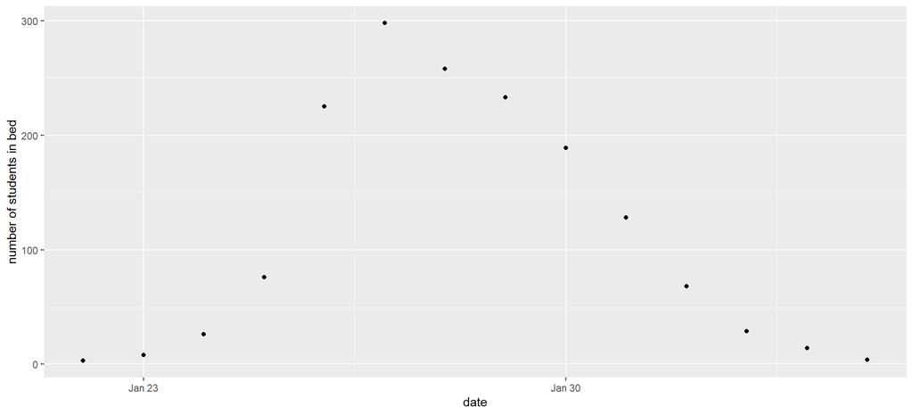

```r
df %>% ggplot() +
  geom_point(mapping = aes(x = date, y = in_bed)) +
  labs(y = "number of students in bed")
```

# 2 Theoretical description

We consider a [SEIR-model](https://de.wikipedia.org/wiki/SEIR-Modell) given by the following system of differential equations:

$$\begin{aligned}
\frac{dS}{dt} = & -\frac{\beta \cdot S \cdot I}{N}\\
\frac{dE}{dt} = & \frac{\beta \cdot S \cdot I}{N} - \alpha \cdot E\\
\frac{dI}{dt} = & \alpha\cdot E -\gamma\cdot I\\
\frac{dR}{dt} = & \gamma\cdot I
\end{aligned}$$

The disease has started wich one infected individual and hence gives rise to the following initial conditions:

$$\begin{aligned}
S(0) =& N -1\\
E(0) =& 0\\
I(0) =& 1\\
R(0) =& 0
\end{aligned}$$

# 3 Bayesian

## 3.1 Choice of priors

### 3.1.2 $\alpha$

### 3.1.3 $\gamma$

# 4 coding

## 4.1 theory

### 4.1.1 practice

We prepare the data

```r
# data preparation
# time series of cases
cases <- df$in_bed  # Number of students in bed

# total count
N <- 763;

# times
n_days <- length(cases)
t <- seq(0, n_days, by = 1)
t0 = 0
t <- t[-1]

#initial conditions
i0 <- 1
e0 <- 0
s0 <- N - i0
r0 <- 0
y0 = c(S = s0, E = e0, I = i0, R = r0)

# data for Stan
data_sir <- list(n_days = n_days, y0 = y0, t0 = t0, ts = t, N = N, cases = cases)

# number of MCMC steps
niter <- 4000
```

We compile the model an draw samples:

```r
model <- stan_model("./StanFiles/seir_model.stan")

SEIR_samples <- sampling(model,
                         data = data_sir,
                         iter = niter,
                         chains = 4)
```

## 4.2 checking the inference

`Stan` gives us information to evaluate whether the statistical inference is reliable. First we start with a summary table of the results for the parameter of interest. Additionally we will see some useful diagnostics, like `Rhat` and the effective sample size.

```r
pars=c('beta', 'alpha', 'gamma', "R0", "recovery_time")
print(SEIR_samples, pars = pars)
```

```
## Inference for Stan model: seir_model.
## 4 chains, each with iter=4000; warmup=2000; thin=1;
## post-warmup draws per chain=2000, total post-warmup draws=8000.
##
##               mean se_mean   sd 2.5%  25%  50%  75% 97.5% n_eff Rhat
## beta          2.42    0.02 0.51 1.81 2.00 2.30 2.71  3.64  1103    1
## alpha         5.99    0.17 5.01 1.27 2.31 3.92 8.17 19.13   847    1
## gamma         0.53    0.00 0.04 0.46 0.50 0.53 0.55  0.61  1637    1
## R0            4.60    0.03 1.05 3.17 3.78 4.38 5.22  7.06  1107    1
## recovery_time 1.90    0.00 0.14 1.63 1.81 1.90 1.98  2.17  1597    1
##
## Samples were drawn using NUTS(diag_e) at Thu Dec 03 18:28:59 2020.
## For each parameter, n_eff is a crude measure of effective sample size,
## and Rhat is the potential scale reduction factor on split chains (at
## convergence, Rhat=1).
```

Moreover a trace plot can be used to evaluate if the chains were able to explore the parameter space or got stuck in an area:

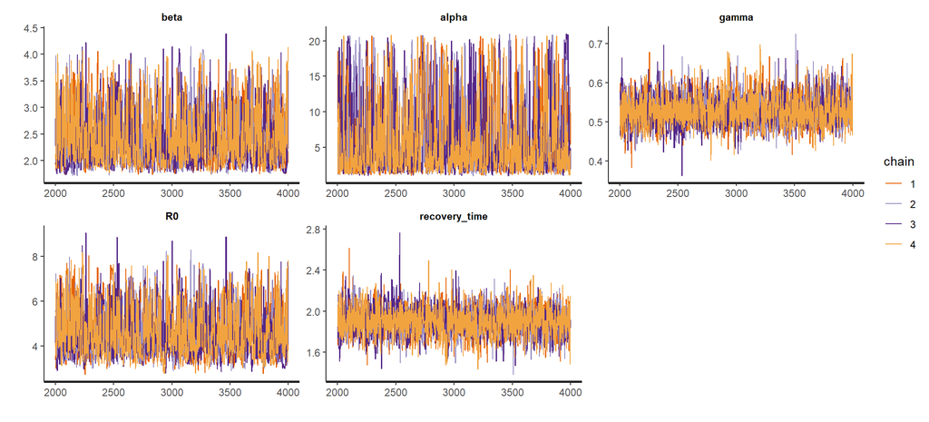

```r
traceplot(SEIR_samples, pars = pars)
```

But we can also check the posterior distribution of our parameters of interest for each marcov chain. Precisely we can check whether they agree with one another or not:

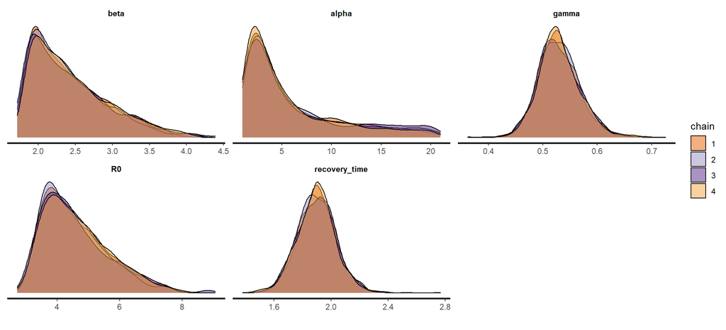

```r
stan_dens(SEIR_samples, pars = pars, separate_chains = TRUE)
```

Let us recall the meaning of the parameters

- $\beta$ is the infection rate, assumed to be constant,
- $\alpha$ is the incubation rate, assumed to be constant,
- $\gamma$ is the recovery rate, assumed to be constant,
- $R_0$ is the (basic) reproduction number